# Guide d’achat de diamants

**Le fichier Rmd est à modifier !!!**

*Vous DEVEZ ENLEVER les parties qui concernent les explications et les exemples pour les REMPLACER par votre PROPRE TRAVAIL !!!!!!!*

N’oubliez pas d’enregistrer votre travail à la fin de la séance.

## Description statistique des différentes variables

En fonction du type de variable (qualitative/quantitative) vous choisirez le graphique adapté ou les résumés numériques intéressants (moyenne, médiane, déciles). Puis vous donnerez quelques commentaires.

### La couleur

On peut faire apparaître le code R et le résultat de l’exécution ainsi :

```r
# combien de diamants pour chaque couleur ?
diamonds %>%
  group_by(color) %>%
  summarise(frequence = round(n() / nrow(diamonds), 2), nombre = n())
```

```
## # A tibble: 7 × 3
##   color frequence nombre
##   <ord>     <dbl>  <int>
## 1 D          0.13   6775
## 2 E          0.18   9797
## 3 F          0.18   9542
## 4 G          0.21  11292
## 5 H          0.15   8304
## 6 I          0.1    5422
## 7 J          0.05   2808
```

La couleur la moins fréquente est la J (la pire) avec 5% des diamants. Pour les autres couleurs la fréquence se situe entre 10% (la couleur I) et 21% (la couleur G).

### La qualité de la coupe

```r
# combien de diamants pour chaque qualité de coupe ?
diamonds %>%
  group_by(cut) %>%
  summarise(frequence = round(n() / nrow(diamonds), 2), nombre = n()) %>%
  arrange(desc(frequence))
```

```
## # A tibble: 5 × 3
##   cut       frequence nombre
##   <ord>         <dbl>  <int>
## 1 Ideal          0.4   21551
## 2 Premium        0.26  13791
## 3 Very Good      0.22  12082
## 4 Good           0.09   4906
## 5 Fair           0.03   1610
```

3 % des diamants ont une mauvaise qualité, heureusement c’est la qualité la moins présente parmi les diamants analysés. Par ailleurs, la qualité la plus fréquente est la qualité idéale avec 40 % des diamants, c’est la meilleure qualité qu’un diamant peut avoir. En somme, on remarque qu’en classant les diamants par leur qualité, on obtient le même classement qu’en les triant par fréquence.

### La clarté

La clarté est une variable qualitative ordinale donc on peut faire un diagramme en barres en ordonnant l’axe des x de la qualité la moins bonne à la meilleure (ou l’inverse). Il peut aussi être intéressant de regrouper des catégories de clarté comme ci-dessous :

```
## # A tibble: 5 × 3
##   clarte                 frequence nombre
##   <ord>                      <dbl>  <int>
## 1 Visible                     0.01    741
## 2 Petites inclusions          0.41  22259
## 3 Minuscules inclusions       0.38  20429
## 4 Difficilement visibles      0.16   8721
## 5 Pur                         0.03   1790
```

1 % des diamants ont des inclusions visibles. Seulement 3 % des diamants ne présentent aucune inclusion et sont donc considérés comme étant purs. Le reste des diamants, la grande majorité (95 %), présente des inclusions assez petites notamment 41 % des diamants qui possèdent de petites inclusions.

### Le nombre de carats

**Mais qu’est-ce qu’un carat ??**

Exemples possibles de présentation : Les instructions R peuvent être cachées avec la commande echo=FALSE, voici la moyenne et la valeur médiane de la variable CARAT

```
## # A tibble: 1 × 7
##   minimum moyenne maximum    Q1 médiane    Q3    D9
##     <dbl>   <dbl>   <dbl> <dbl>   <dbl> <dbl> <dbl>
## 1     0.2   0.798    5.01   0.4     0.7  1.04  1.51
```

**Que signifie que D9=1.51 ?**

Cela signifie que 90% (9ième décile) des diamants ont un carat inférieur ou égale à 1.51.

On peut bien sûr inclure des graphiques :

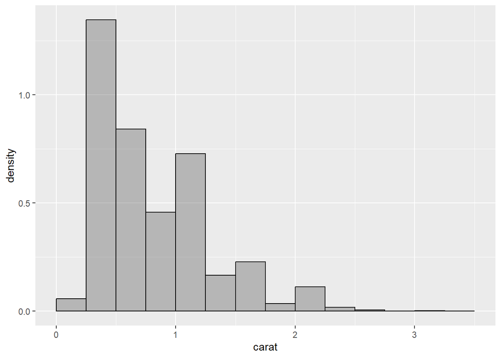

```r
ggplot(diamonds) +
  geom_histogram(aes(x = carat, y = ..density..), breaks = seq(0, 3.5, 0.25), fill = "grey40", color = "black", alpha = 0.4)
```

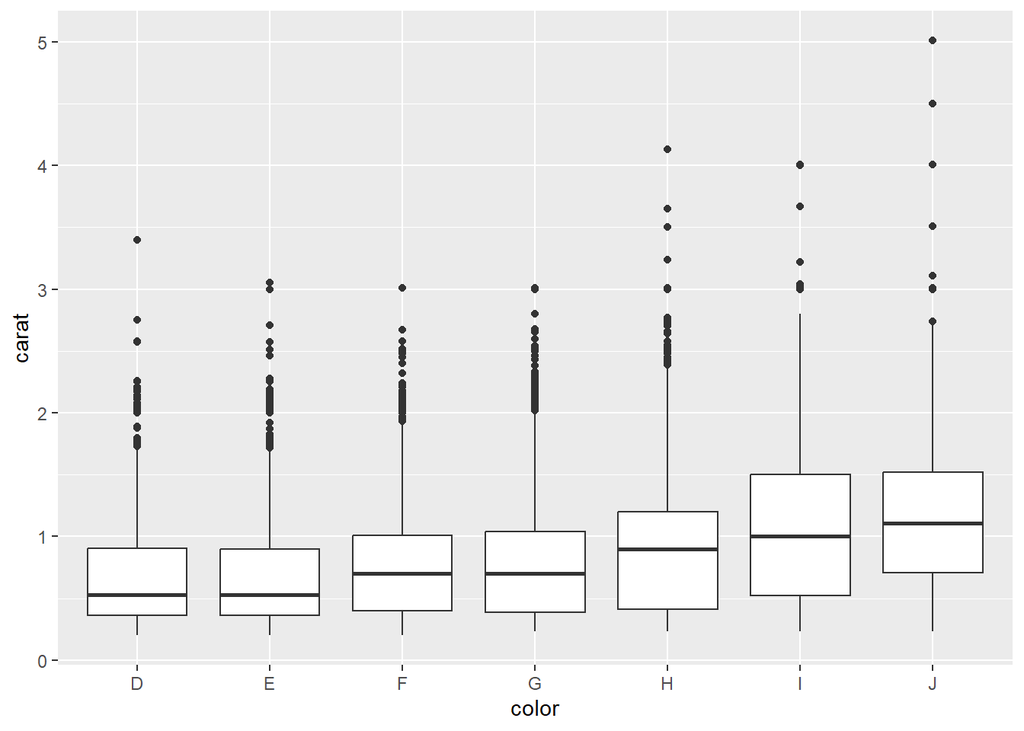

```r
ggplot(diamonds, aes(x = color, y = carat)) +
  geom_boxplot()
```

En regardant de plus près, c’est-à-dire en précisant que chaque intervalle sur l’axe des abscisses doit être de 0,01 et en ne considérant que les diamants de moins de 1,51 carats (soit 90% des diamants), on constate ceci :

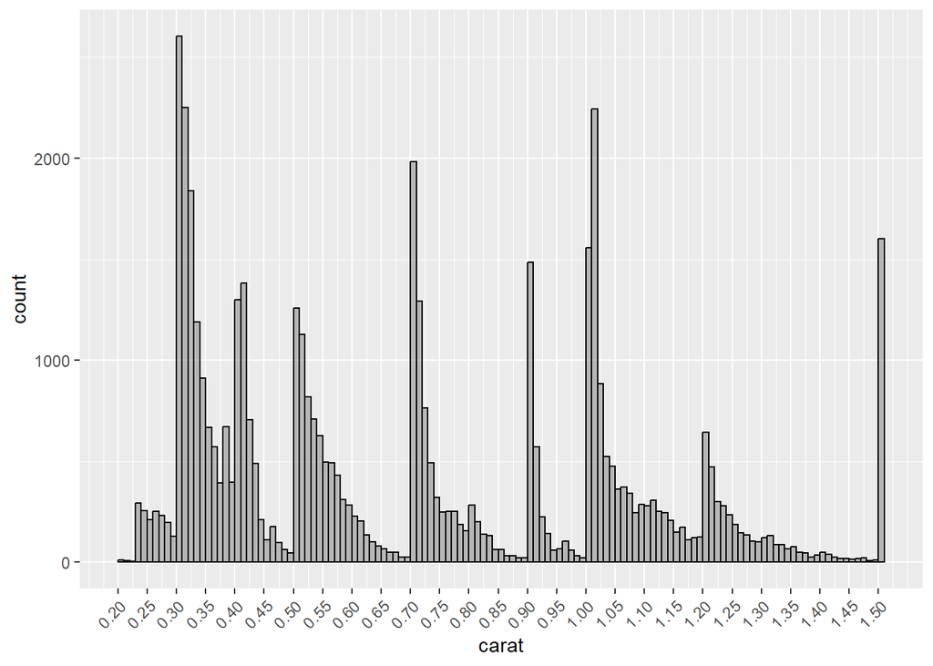

```r
diamonds %>%
  filter(carat <= 1.51) %>%
  ggplot() +
  geom_histogram(aes(x = carat),
    breaks = (seq(0.2, 1.51, by = 0.01)),
    closed = "left", fill = "grey40", color = "black", alpha = 0.4
  ) +
  scale_x_continuous(breaks = seq(0.2, 1.51, by = 0.05)) +
  theme(axis.text.x = element_text(angle = 45, hjust = 1))
```

### La table

[figure not shown]

## Comment s’explique le prix d’un diamant ? -> A faire en séance 2

Pourquoi prendre le log du prix ? On constate dans le tableau suivant que l’étendue des prix est très grande.

```r
diamonds%>%summarise(minimum = min(price),Q1 = quantile(price, 0.25), moyenne = round(mean(price), 0),  mediane = median(price), Q3 = quantile(price, 0.75), maximum=max(price))
```

```
## # A tibble: 1 × 6
##   minimum    Q1 moyenne mediane    Q3 maximum
##     <int> <dbl>   <dbl>   <dbl> <dbl>   <int>
## 1     326   950    3933    2401 5324.   18823
```

La distribution avec l’axe des x en échelle logarithmique :

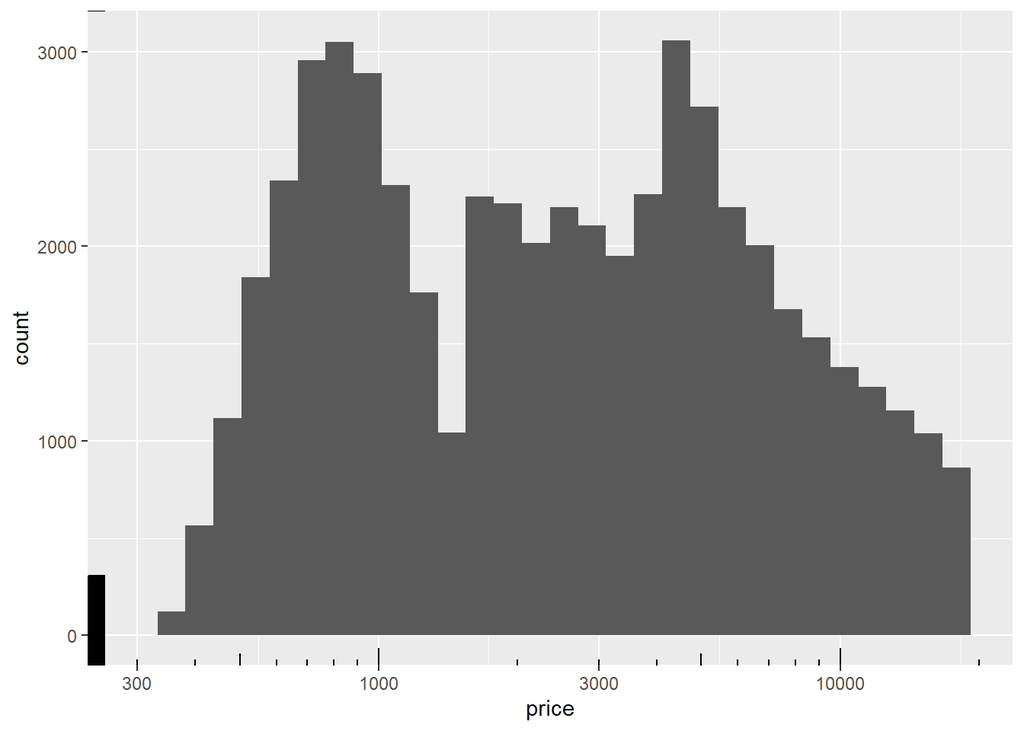

Une autre façon de faire : tracer l’histogramme de log(price) mais là on voit que l’axe des x n’est plus en dollars !!!

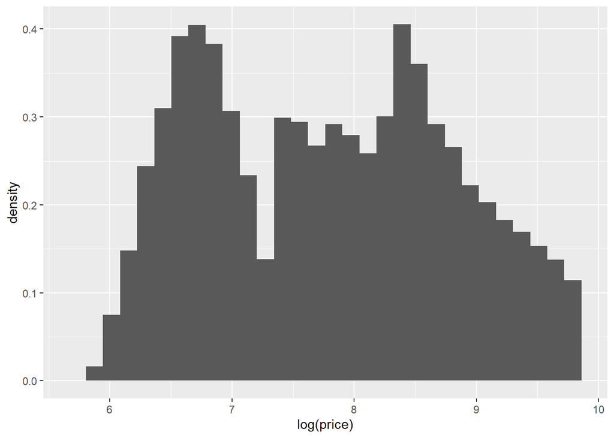

Quelques statistiques sur le logarithme du prix en fonction de la qualité de la coupe :

```
## # A tibble: 5 × 3
##   cut       moyenne médiane
##   <ord>       <dbl>   <dbl>
## 1 Fair         8.09    8.10
## 2 Good         7.84    8.02
## 3 Very Good    7.80    7.88
## 4 Premium      7.95    8.07
## 5 Ideal        7.64    7.50
```

Et quelques autres graphiques à titre d’exemples

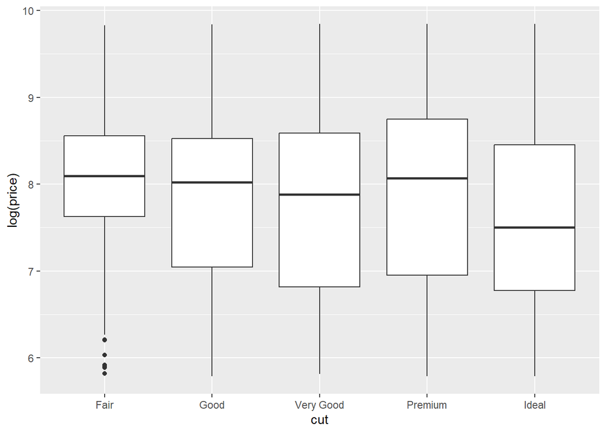

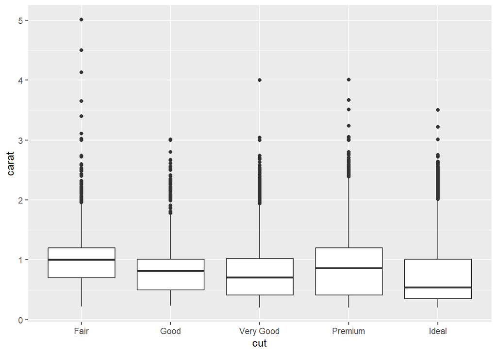

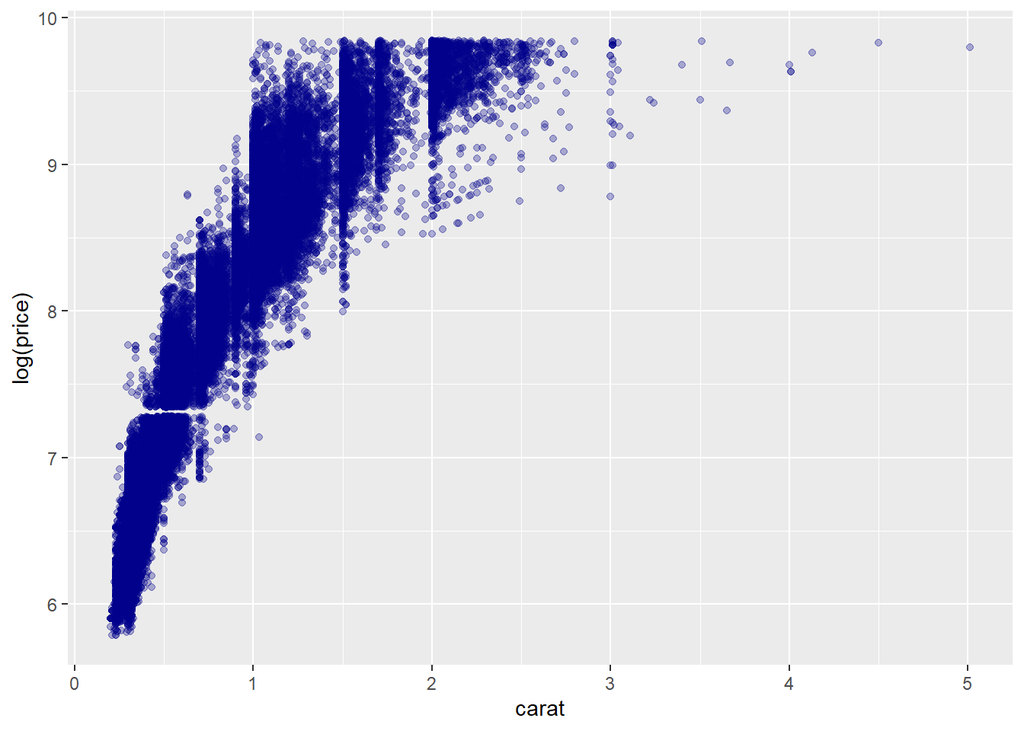

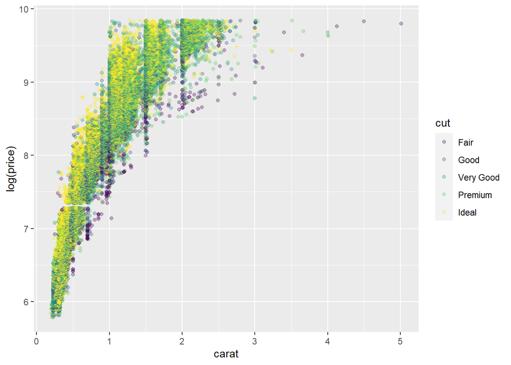

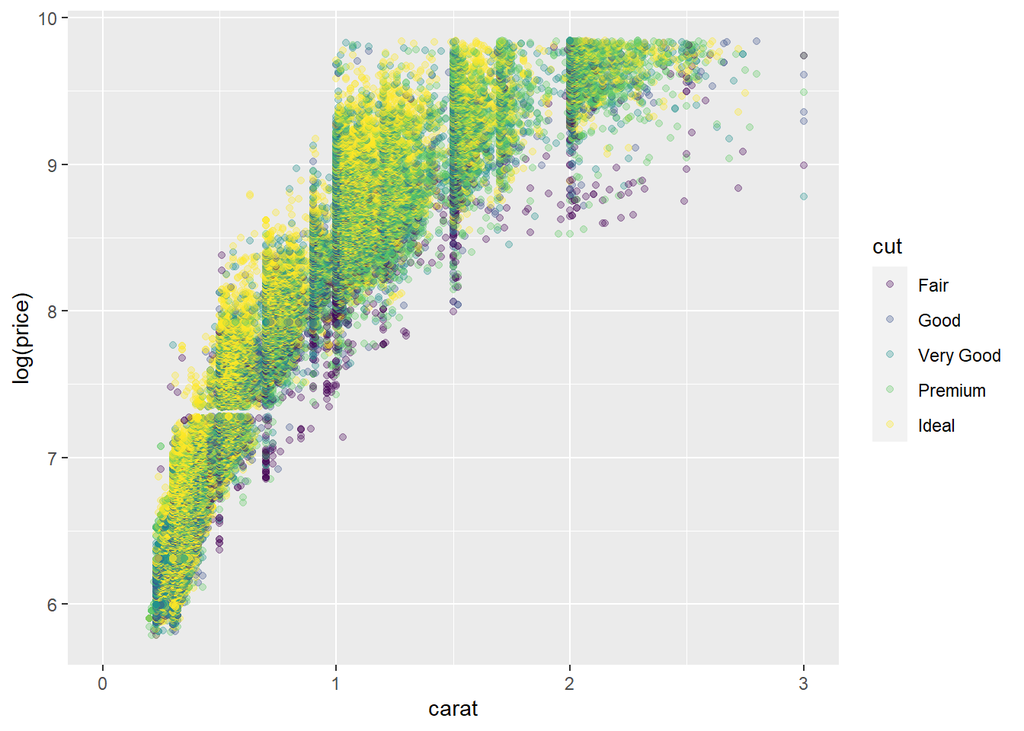

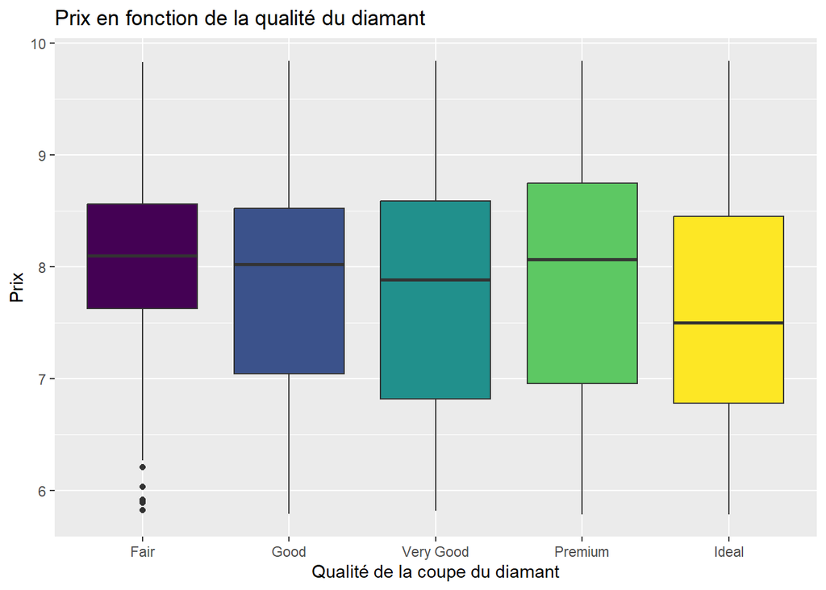

On remarque que la qualité de coupe d’un diamant n’a pas l’air d’avoir d’importance dans le prix du diamant. On remarque même que pour une qualité basse (fair) la mediane de prix et le premier quartile sont supérieurs à la médiane et premier quartile des prix pour une qualité élevé (ideal).

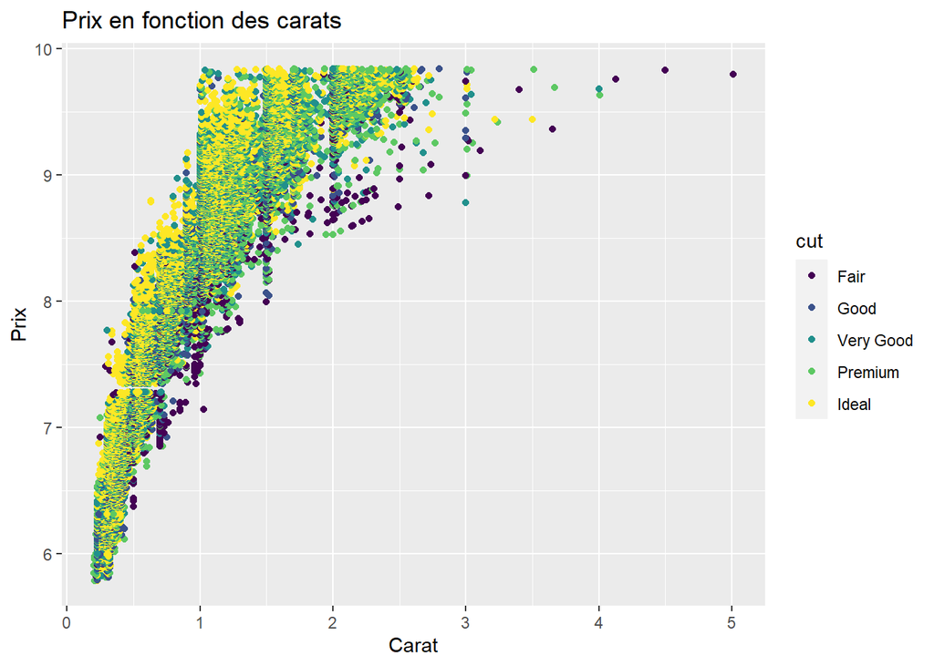

Sur ce graphique on voit que plus le carat d’un diamant est important plus son prix augmente. Au-dessus de 2 carats, les prix sont contenus entre 8 et 10 ; en dessous de 2 carats, le prix descend jusqu’à 6. Enfin, au-dessus de 3 carats, on remarque que le minimum de prix est 9. On remarque donc bien que plus le diamant a un carat élevé plus son prix l’est aussi.

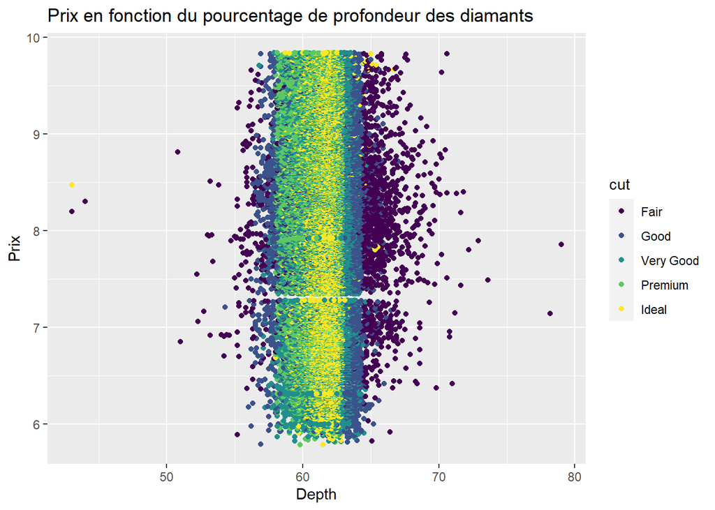

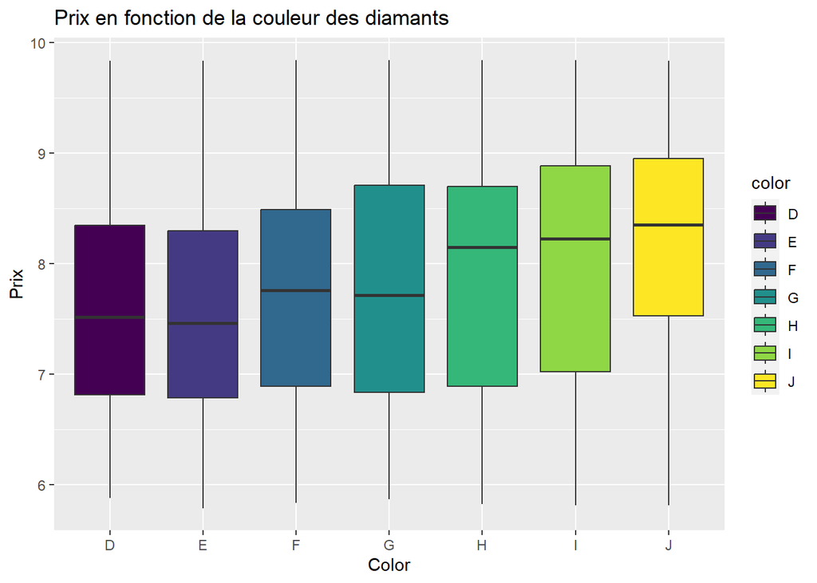

Ce graphique nous montre que la couleur peut avoir une influence sur le prix d’un diamant, ici, on remarque que les diamants de couleur J ont une médiane de prix supérieur à ceux de la couleur D.

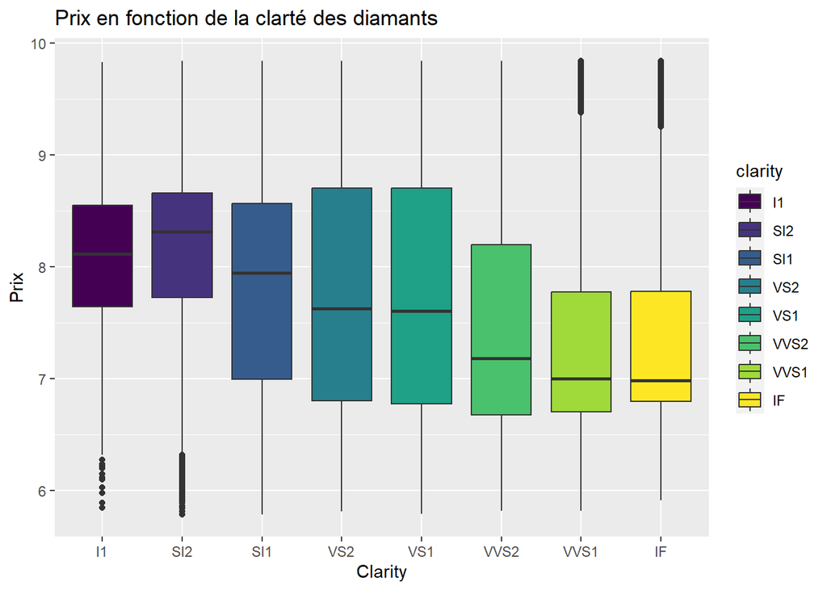

```r
ggplot(diamonds, aes(x = clarity, y = log(price), fill=clarity)) +
  geom_boxplot() +
  labs(title = "Prix en fonction de la clarté des diamants",
       x = "Clarity",
       y = "Prix")
```

La clarté IF qui est la meilleure clarté possible à une médiane des prix inférieur (et son premier quartile) à ceux des qualités VS1 à I1, I1 représentant des diamants avec inclusions visible. Ceci nous montre donc que la clarté d’un diamant n’influe pas sur son prix.

[figure not shown]

En effet, cela pouvait paraître illogique en voyant que la clarté d’un diamant ne joue pas un rôle important dans son prix or ce graphique la nous montre que les diamants avec la meilleure qualité possible sont aussi les plus petits possible et inversement. Encore une fois, on remarque donc que ce sont bien les carats d’un diamant qui détermine un rôle plus que majeur dans la determination d’un prix pour un diamant.

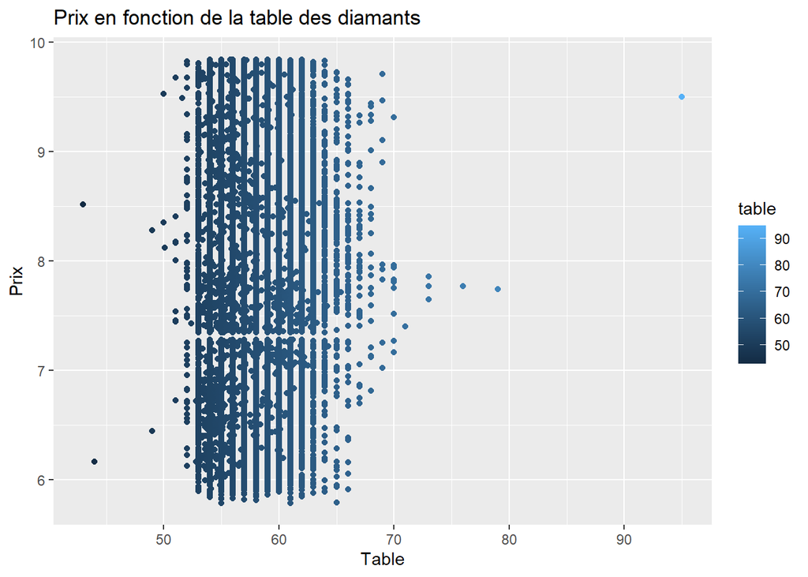

```r
ggplot(diamonds, aes(x = table, y = log(price), color=table)) +
  geom_point() +
  labs(title = "Prix en fonction de la table des diamants",
       x = "Table",
       y = "Prix")
```